# Parametric models

```r
library(serosv)
library(dplyr)
library(magrittr)
```

## Polynomial models

Refer to `Chapter 6.1.1`

Use `polynomial_model()` to fit a polynomial model.

```r
data <- hav_bg_1964
```

### Muench model

**Proposed model**

(Muench 1934) suggested to model the infection process with so-called “catalytic model”, in which the distribution of the time spent in the susceptible class in SIR model is exponential with rate $\beta$

$$\pi(a) = k(1 - e^{-\beta a} )$$

Where:

- $\pi$ is the seroprevalence at age $a$
- $1 - k$ is the proportion of population that stay uninfected for a lifetime
- $a$ is the variable age

Under this catalytic model and assuming that $k = 1$, force infection would be $\lambda(a) = \beta$

**Fitting data**

**Muench**’s model can be estimated by either defining `k = 1` (a degree one linear predictor, note that it is irrelevant to the k in the proposed model) or setting the `type = "Muench"`.

```r
muench1 <- polynomial_model(data, k = 1)
summary(muench1$info)
```

```
#>
#> Call:
#> glm(formula = age(k), family = binomial(link = link), data = df)
#>
#> Coefficients:
#>      Estimate Std. Error z value Pr(>|z|)
#> Age -0.050500   0.002457  -20.55   <2e-16 ***
#> ---
#> Signif. codes:  0 '***' 0.001 '**' 0.01 '*' 0.05 '.' 0.1 ' ' 1
#>
#> (Dispersion parameter for binomial family taken to be 1)
#>
#>     Null deviance:    Inf  on 83  degrees of freedom
#> Residual deviance: 97.275  on 82  degrees of freedom
#> AIC: 219.19
#>
#> Number of Fisher Scoring iterations: 5
```

```r
muench2 <- polynomial_model(data, type = "Muench")
summary(muench2$info)
```

```
#>
#> Call:
#> glm(formula = age(k), family = binomial(link = link), data = df)
#>
#> Coefficients:
#>      Estimate Std. Error z value Pr(>|z|)
#> Age -0.050500   0.002457  -20.55   <2e-16 ***
#> ---
#> Signif. codes:  0 '***' 0.001 '**' 0.01 '*' 0.05 '.' 0.1 ' ' 1
#>
#> (Dispersion parameter for binomial family taken to be 1)
#>
#>     Null deviance:    Inf  on 83  degrees of freedom
#> Residual deviance: 97.275  on 82  degrees of freedom
#> AIC: 219.19
#>
#> Number of Fisher Scoring iterations: 5
```

We can plot any model with the `plot()` function.

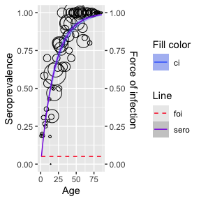

```r
plot(muench2)
```

### Griffith model

**Proposed model**

Griffith proposed a model for force of infection as followed

$$\lambda(a) = \beta_1 + 2\beta_2a$$

Which can be estimated using a GLM where the for which the linear predictor was $\eta(a) = \beta_1 + \beta_2a^{2}$

**Fitting data**

Similarly, we can estimate **Griffith**’s model either by defining `k = 2`, or setting the `type = "Griffith"`

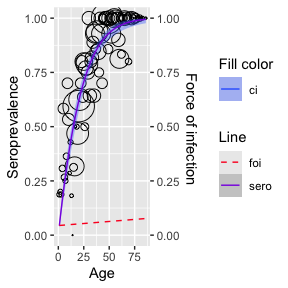

```r
gf_model <- polynomial_model(data, type = "Griffith")
plot(gf_model)
```

### Grenfell and Anderson model

**Proposed model**

(Grenfell and Anderson 1985) extended the models of Muench and Griffiths further suggest the use of higher order polynomial functions to model the force of infection which assumes prevalence model as followed

$$\pi(a) = 1 - e^{-\Sigma_i \beta_i a^i}$$

Which implies that force of infection equals $\lambda(a) = \Sigma \beta_i i a^{i-1}$

**Fitting data**

And Grenfell and Anderson’s model.

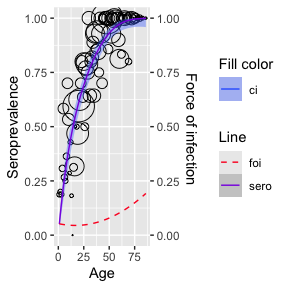

```r
grf_model <- polynomial_model(data, type = "Grenfell")
plot(grf_model)
```

## Nonlinear models

Refer to `Chapter 6.1.2`

### Farrington model

**Proposed model**

For Farrington’s model, the force of infection was defined non-negative for all a $\lambda(a) \geq 0$ and increases to a peak in a linear fashion followed by an exponential decrease

$$\lambda(a) = (\alpha a - \gamma)e^{-\beta a} + \gamma$$

Where $\gamma$ is called the long term residual for FOI, as $a \rightarrow \infty$ , $\lambda (a) \rightarrow \gamma$

Integrating $\lambda(a)$ would results in the following non-linear model for prevalence

$$\pi (a) = 1 - e^{-\int_0^a \lambda(s) ds} \\ = 1 - exp\{
\frac{\alpha}{\beta}ae^{-\beta a} + \frac{1}{\beta}(\frac{\alpha}{\beta}
- \gamma)(e^{-\beta a} - 1) -\gamma a \}$$

**Fitting data**

Use `farrington_model()` to fit a **Farrington**’s model.

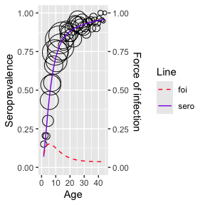

```r
farrington_md <- farrington_model(
   rubella_uk_1986_1987,
   start=list(alpha=0.07,beta=0.1,gamma=0.03)
   )
plot(farrington_md)
```

### Weibull model

**Proposed model**

For a Weibull model, the prevalence is given by

$$\pi (d) = 1 - e^{ - \beta_0 d ^ {\beta_1}}$$

Where $d$ is exposure time (difference between age of injection and age at test)

The model was reformulated as a GLM model with log - log link and linear predictor using log(d)

$$\eta(d) = log(\beta_0) + \beta_1
log(d)$$

Thus implies that the force of infection is a monotone function of the exposure time as followed

$$\lambda(d) = \beta_0 \beta_1 d^{\beta_1 - 1}$$

**Fitting data**

Use `weibull_model()` to fit a Weibull model.

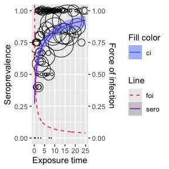

```r
hcv <- hcv_be_2006[order(hcv_be_2006$dur), ]

wb_md <- hcv %>%
  rename(
    t = dur, status = seropositive
  ) %>% weibull_model()
plot(wb_md)
```

## Fractional polynomial model

Refer to `Chapter 6.2`

**Proposed model**

Fractional polynomial model generalize conventional polynomial class of functions. In the context of binary responses, a fractional polynomial of degree $m$ for the linear predictor is defined as followed

$$\eta_m(a, \beta, p_1, p_2, ...,p_m) = \Sigma^m_{i=0} \beta_i H_i(a)$$

Where $m$ is an integer, $p_1 \le p_2 \le... \le p_m$ is a sequence of powers, and $H_i(a)$ is a transformation given by

$$H_i = \begin{cases}
a^{p_i} & \text{ if } p_i \neq p_{i-1},
\\ H_{i-1}(a) \times log(a) & \text{ if } p_i = p_{i-1},
\end{cases}$$

**Best power selection**

Use `find_best_fp_powers()` to find the powers which gives the lowest deviance score

```r
hav <- hav_be_1993_1994
best_p <- find_best_fp_powers(
  hav,
  p=seq(-2,3,0.1), mc=FALSE, degree=2, link="cloglog"
)
best_p
```

```
#> $p
#> [1] 1.5 1.6
#>
#> $deviance
#> [1] 81.60333
#>
#> $model
#>
#> Call:  glm(formula = as.formula(formulate(p_cur)), family = binomial(link = link))
#>
#> Coefficients:
#> (Intercept)   I(age^1.5)   I(age^1.6)
#>    -3.61083      0.12443     -0.07656
#>
#> Degrees of Freedom: 85 Total (i.e. Null);  83 Residual
#> Null Deviance:       1320
#> Residual Deviance: 81.6  AIC: 361.2
```

**Fitting data**

Use `fp_model()` to fit a fractional polynomial model

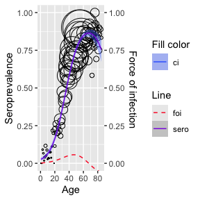

```r
model <- fp_model(hav, p=c(1.5, 1.6), link="cloglog")
plot(model)
```

Grenfell, B. T., and R. M. Anderson. 1985. “The Estimation of Age-Related Rates of Infection from Case Notifications and Serological Data.” *The Journal of Hygiene* 95 (2): 419–36. https://doi.org/10.1017/s0022172400062859.

Muench, Hugo. 1934. “Derivation of Rates from Summation Data by the Catalytic Curve.” *Journal of the American Statistical Association* 29 (185): 25–38. https://doi.org/10.1080/01621459.1934.10502684.